# Benchmark

Leonardo A. Santella

November 9, 2016

## Introducción

Se requiere la realización de gráficos comparativos en cuanto a los tiempos arrojados por el comando ‘time’ de la consola de Linux, al ejecutar un programa que realiza una suma de vectores/matrices en secuencial, versus, otro programa que realiza la misma tarea, pero de forma paralela.

El paralelismo fue implementado con las primitivas de OpenMP. El Sistema Operativo utilizado fue Ubuntu 16.04 LTS. El Procesador utilizado para el experimento fue un Intel Core i7.

## Comparación

A continuación, se encuentra la declaración de los vectores de datos obtenidos en el experimento

```r
user_parallel = c(0, 0, 0, 0, 0.02, 0.21, 2.04, 20.82)
user_seq = c(0, 0, 0, 0, 0, 0.05, 0.26, 2.09)
cpu_parallel = c(0, 0, 0, 0, 0.04, 0.47, 4.58, 50.26)
cpu_seq = c(0, 0, 0, 0, 0, 0, 0.02, 0.05)
elapsed_parallel = c(0, 0, 0, 0, 0.02, 0.21, 2.04, 20.82)
elapsed_seq = c(0, 0, 0, 0, 0, 0.05, 0.29, 2.11)
```

## Tiempo de ejecución en segundos

El color azul caracteriza a los tiempos del programa en paralelo y las líneas de color rojo identifican a los tiempos del programa ejecutado de forma secuencial.

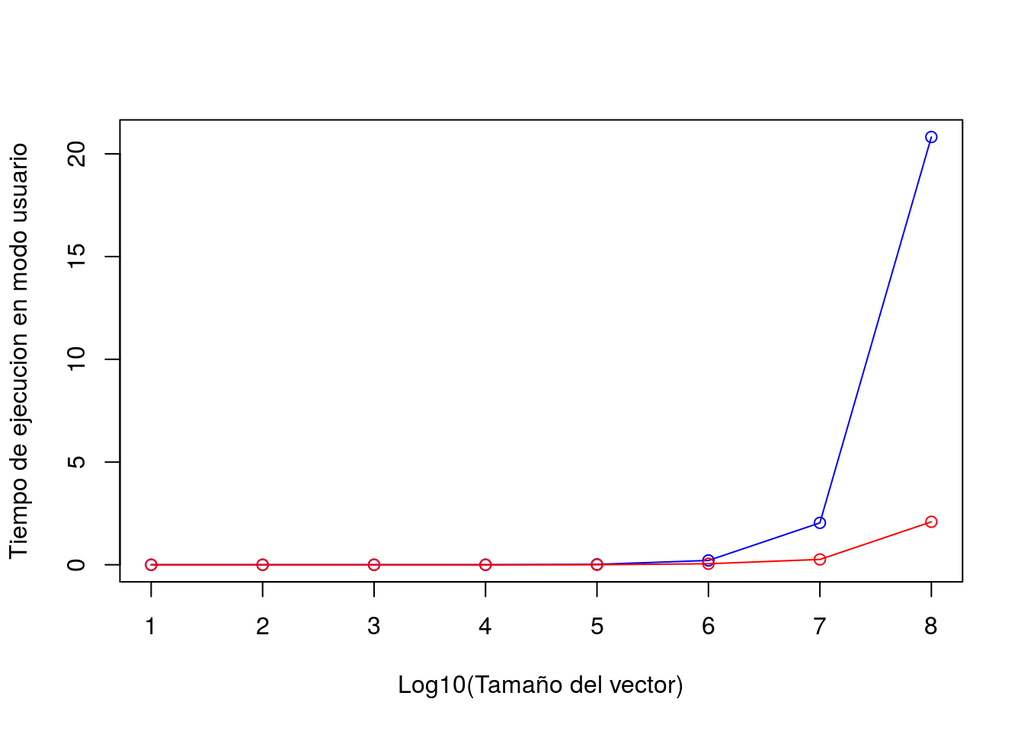

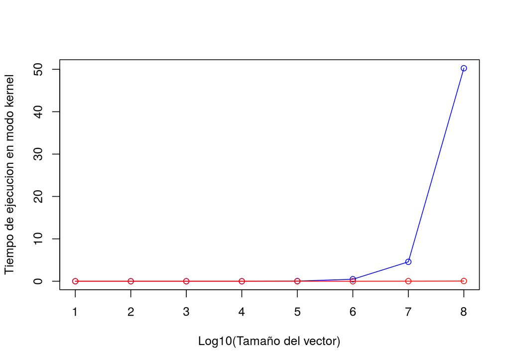

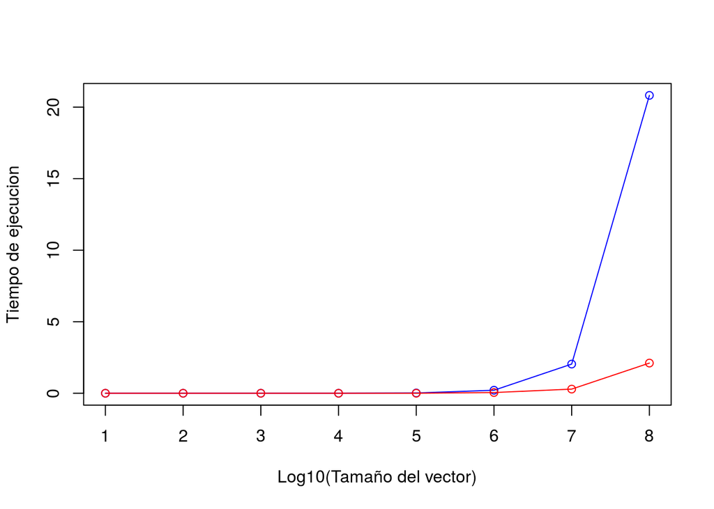

Es importante resaltar que existen casos en donde la ejecución en modo kernel sobrepas los tiempos de ejecución per se.